# Kaggle: Titanic Survival

Emma Ideal

September 1, 2015

## Getting the Data

I first downloaded the data from the Kaggle website, and now I read in the data:

```r
training <- read.csv('train.csv')
testing  <- read.csv('test.csv')
str(training)
```

```
## 'data.frame':    891 obs. of  12 variables:
##  $ PassengerId: int  1 2 3 4 5 6 7 8 9 10 ...
##  $ Survived   : int  0 1 1 1 0 0 0 0 1 1 ...
##  $ Pclass     : int  3 1 3 1 3 3 1 3 3 2 ...
##  $ Name       : Factor w/ 891 levels "Abbing, Mr. Anthony",..: 109 191 358 277 16 559 520 629 417 581 ...
##  $ Sex        : Factor w/ 2 levels "female","male": 2 1 1 1 2 2 2 2 1 1 ...
##  $ Age        : num  22 38 26 35 35 NA 54 2 27 14 ...
##  $ SibSp      : int  1 1 0 1 0 0 0 3 0 1 ...
##  $ Parch      : int  0 0 0 0 0 0 0 1 2 0 ...
##  $ Ticket     : Factor w/ 681 levels "110152","110413",..: 524 597 670 50 473 276 86 396 345 133 ...
##  $ Fare       : num  7.25 71.28 7.92 53.1 8.05 ...
##  $ Cabin      : Factor w/ 148 levels "","A10","A14",..: 1 83 1 57 1 1 131 1 1 1 ...
##  $ Embarked   : Factor w/ 4 levels "","C","Q","S": 4 2 4 4 4 3 4 4 4 2 ...
```

```r
str(testing)
```

```
## 'data.frame':    418 obs. of  11 variables:
##  $ PassengerId: int  892 893 894 895 896 897 898 899 900 901 ...
##  $ Pclass     : int  3 3 2 3 3 3 3 2 3 3 ...
##  $ Name       : Factor w/ 418 levels "Abbott, Master. Eugene Joseph",..: 210 409 273 414 182 370 85 58 5 104 ...
##  $ Sex        : Factor w/ 2 levels "female","male": 2 1 2 2 1 2 1 2 1 2 ...
##  $ Age        : num  34.5 47 62 27 22 14 30 26 18 21 ...
##  $ SibSp      : int  0 1 0 0 1 0 0 1 0 2 ...
##  $ Parch      : int  0 0 0 0 1 0 0 1 0 0 ...
##  $ Ticket     : Factor w/ 363 levels "110469","110489",..: 153 222 74 148 139 262 159 85 101 270 ...
##  $ Fare       : num  7.83 7 9.69 8.66 12.29 ...
##  $ Cabin      : Factor w/ 77 levels "","A11","A18",..: 1 1 1 1 1 1 1 1 1 1 ...
##  $ Embarked   : Factor w/ 3 levels "C","Q","S": 2 3 2 3 3 3 2 3 1 3 ...
```

The training set contains 12 columns, while the testing set contains 11 columns - the ‘Survived’ outcome is not supplied in the testing set.

## Imputing missing values

It looks like there are missing values in the training set:

```r
sum(is.na(training$Age))
```

```
## [1] 177
```

```r
sum(training$Cabin=='')
```

```
## [1] 687
```

```r
sum(training$Embarked=='')
```

```
## [1] 2
```

More than 77% of the Cabin values are missing in the training set, giving us little statistics to impute the missing data. This variable will therefore not be useful in prediction.

There are 2 missing values in the Embarked column of the training set. I would like to use k-nearest-neighbors imputation to replace these missing values, but right now, I am having trouble installing the R *imputation* package. Instead, I will look at variables I expect to be correlated with Embarked such as Pclass and Fare:

```r
table(training$Embarked, training$Pclass)
```

```
##
##       1   2   3
##       2   0   0
##   C  85  17  66
##   Q   2   3  72
##   S 127 164 353
```

The missing Embarked values are seen in the first row and first column of the table. These missing values have Pclass = 1; the majority of Pclass = 1 values fall in the ‘S’ Embarked category.

```r
farecut <- cut(training$Fare, breaks=c(0,40,70,80,90,120,160,200,max(training$Fare)), include.lowest=T)
table(training$Embarked, farecut)
```

```
##    farecut
##     [0,40] (40,70] (70,80] (80,90] (90,120] (120,160] (160,200] (200,512]
##          0       0       2       0        0         0         0         0
##   C    100      18      12       7       13         6         0        12
##   Q     75       0       0       2        0         0         0         0
##   S    540      53      17       8        6        10         2         8
```

The missing Embarked values have Fare = 80. The majority of tickets with fares around 80 fall into category ‘S’ for Embarked. We will replace the missing Embarked values with Embarked = ‘S’.

```r
training$Embarked[training$Embarked==''] <- 'S'
training$Embarked <- droplevels(training$Embarked)
```

Roughly 20% of the Age values in the training set are NA. Since age will likely be a useful covariate for predicting survival, we want to impute this data somehow. We can fit a generalized linear model using the following covariates: Pclass, Sex, SibSp, Parch, Fare, and Embarked.

```r
library(caret)
training$Age[is.na(training$Age)] <- 0
trainingNoNA <- training[training$Age != 0,]
trainingNA <- training[training$Age == 0,]
glm <- train(Age ~ Pclass+Sex+SibSp+Parch+Fare+Embarked, method='glm', data=trainingNoNA)
glm$finalModel
```

```
##
## Call:  NULL
##
## Coefficients:
## (Intercept)       Pclass      Sexmale        SibSp        Parch
##    44.71148     -7.25075      3.20490     -3.89064     -0.78594
##        Fare    EmbarkedQ    EmbarkedS
##    -0.01412      5.22960      2.29890
##
## Degrees of Freedom: 713 Total (i.e. Null);  706 Residual
## Null Deviance:       150500
## Residual Deviance: 114100    AIC: 5667
```

```r
pred <- round(predict(glm, newdata=trainingNA),0)
# Make any negative ages = 0
pred[pred<0] <- 0
```

Now replace these predictions in the trainingNA dataset and row bind the NoNA dataset to this imputed data:

```r
trainingNA$Age <- pred
training <- rbind(trainingNA, trainingNoNA)
```

## Converting the outcome to a factor variable

I will first change the Survived variable to a factor variable, so that the predictions will take on only the values 0 or 1 as opposed to a floating value.

```r
training$Survived <- as.factor(training$Survived)
```

## Exploratory Plots

First make a pairs plot. The first row of the plot matrix shows the relationship between the outcome (Survived) on the y-axis and the possible predictors on the x-axis.

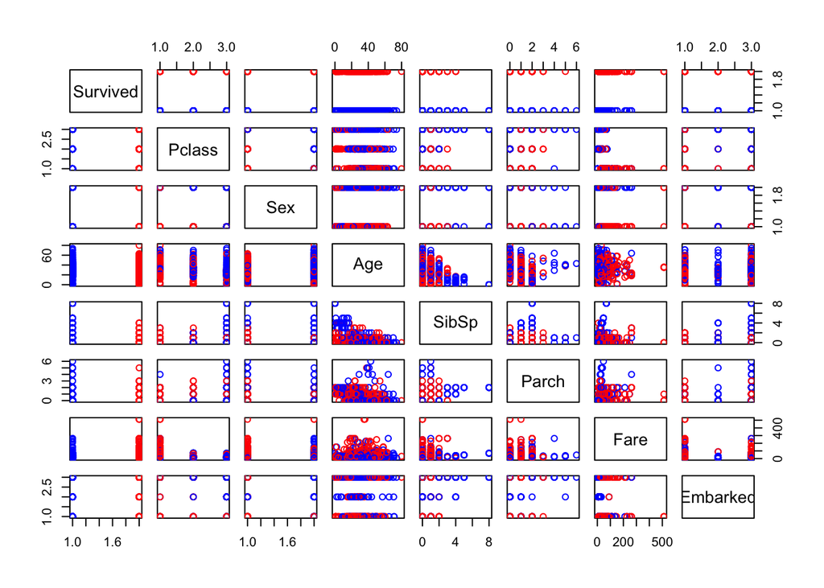

```r
cols <- character(nrow(training))
cols[] <- 'black'
cols[training$Survived %in% '0'] <- 'blue'
cols[training$Survived %in% '1'] <- 'red'
pairs(Survived~Pclass+Sex+Age+SibSp+Parch+Fare+Embarked, data=training, cex.labels=1.3, col=cols)
```

Plot some variables:

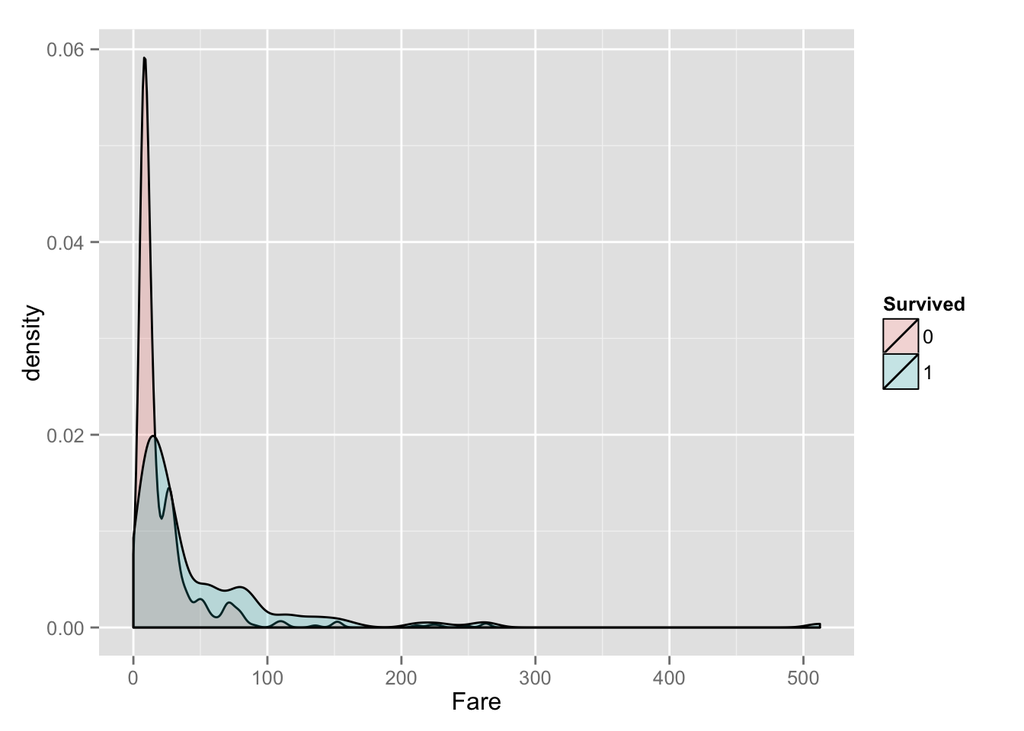

```r
library(ggplot2)
ggplot(training, aes(Fare, fill=Survived)) + geom_density(alpha=0.2)
```

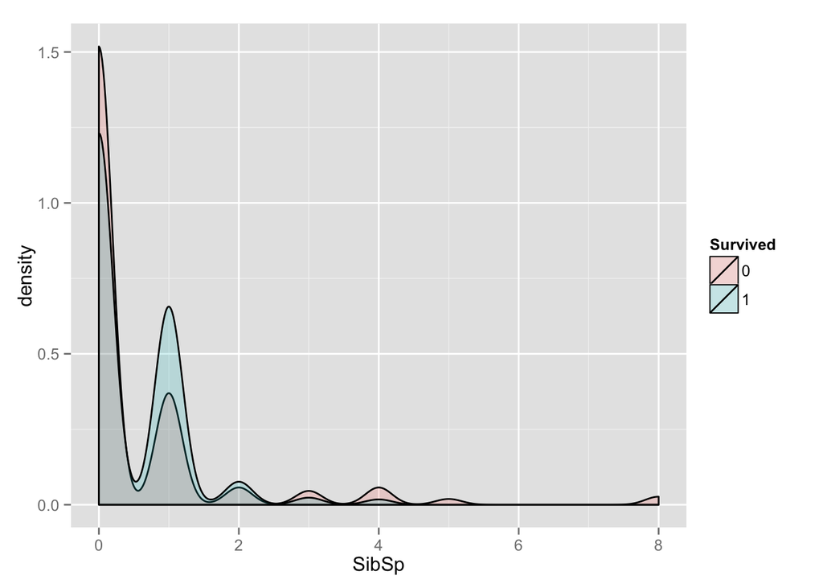

```r
ggplot(training, aes(SibSp, fill=Survived)) + geom_density(alpha=0.2)
```

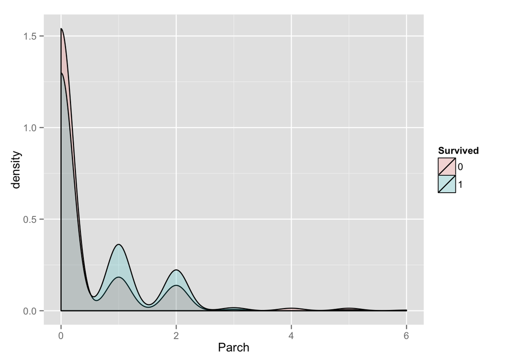

```r
ggplot(training, aes(Parch, fill=Survived)) + geom_density(alpha=0.2)
```

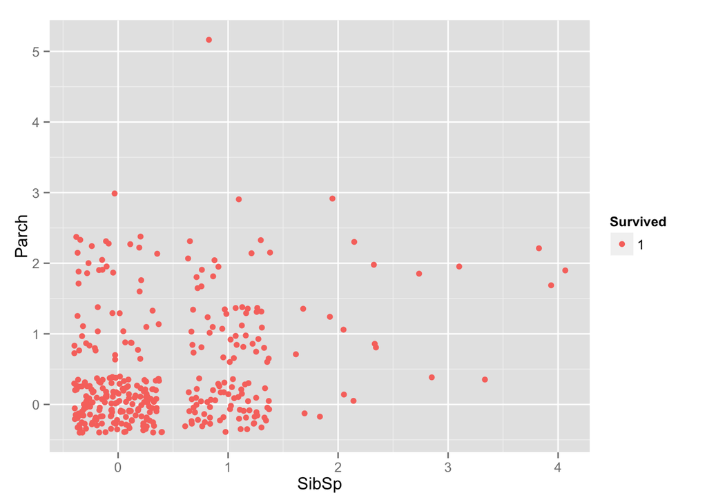

```r
ggplot(training[as.factor(training$Survived)=='1',], aes(x=SibSp, y=Parch)) + geom_jitter(aes(colour = Survived))
```

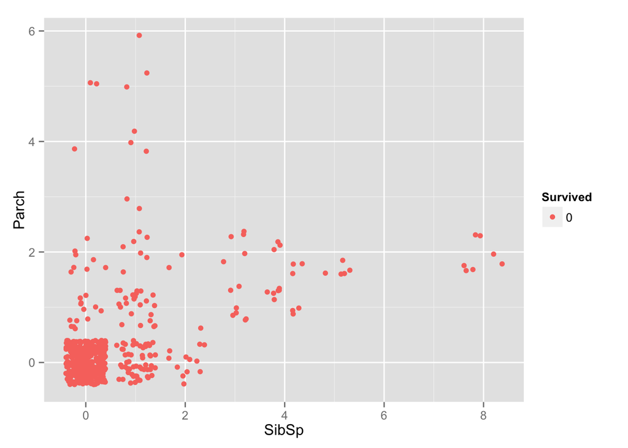

```r
ggplot(training[as.factor(training$Survived)=='0',], aes(x=SibSp, y=Parch)) + geom_jitter(aes(colour = Survived))
```

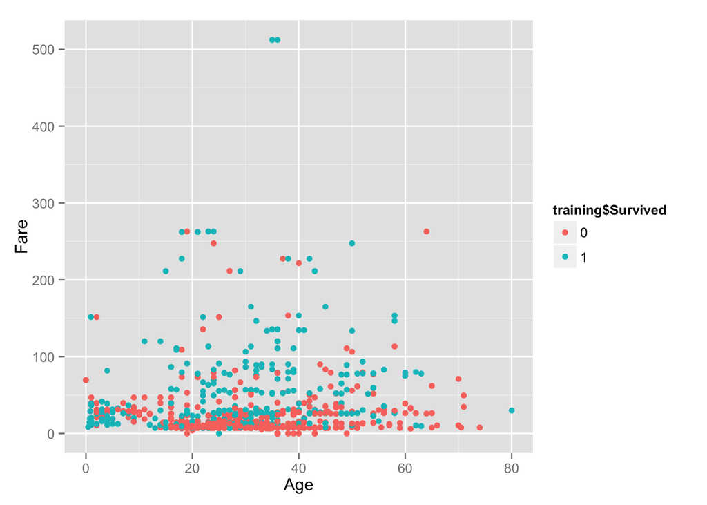

```r
ggplot(training, aes(x=Age, y=Fare)) + geom_point(aes(x=Age, y=Fare, colour=training$Survived))
```

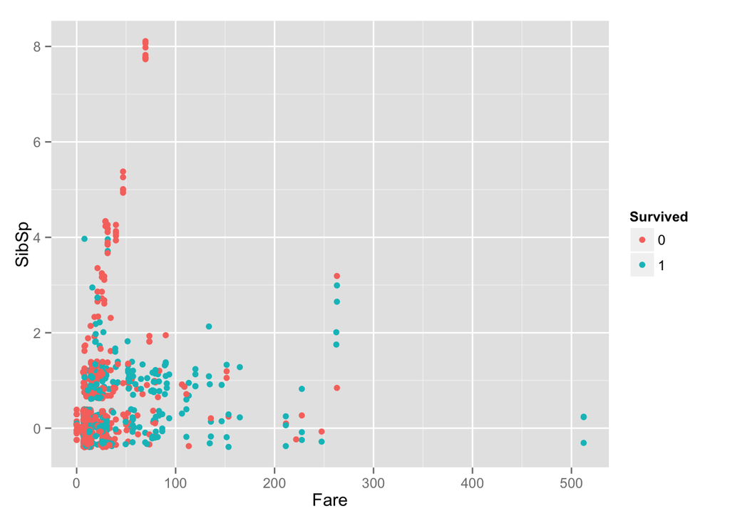

```r
ggplot(training, aes(x=Fare, y=SibSp)) + geom_jitter(aes(colour=Survived))
```

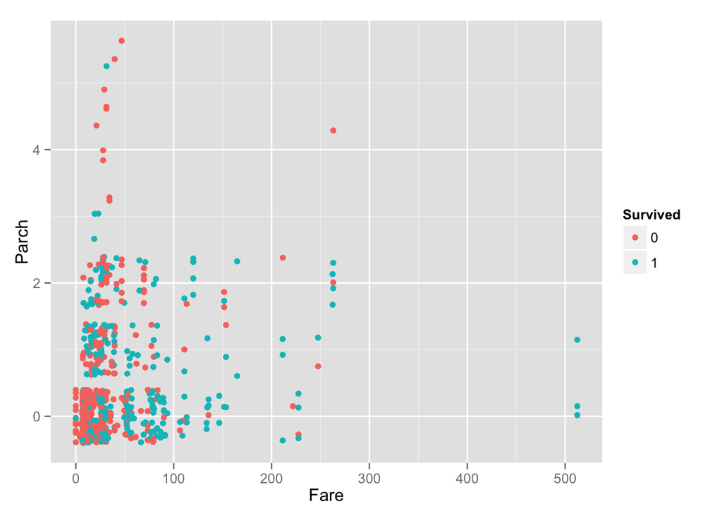

```r
ggplot(training, aes(x=Fare, y=Parch)) + geom_jitter(aes(colour=Survived))
```

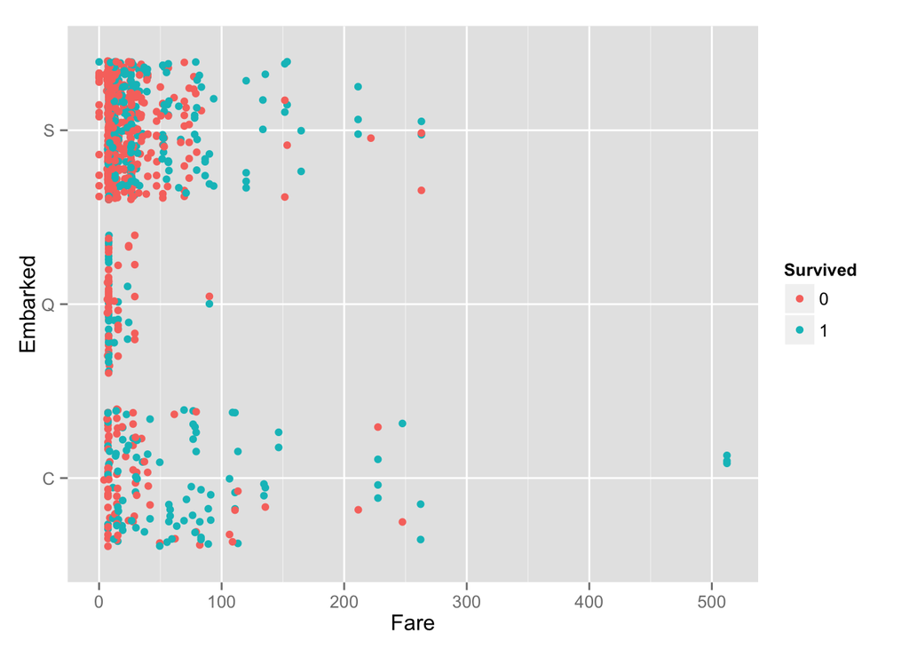

```r
ggplot(training, aes(Fare, y=Embarked)) + geom_jitter(aes(colour=Survived))
```

We can then plot the relationship between Survived and Age, colored by Sex:

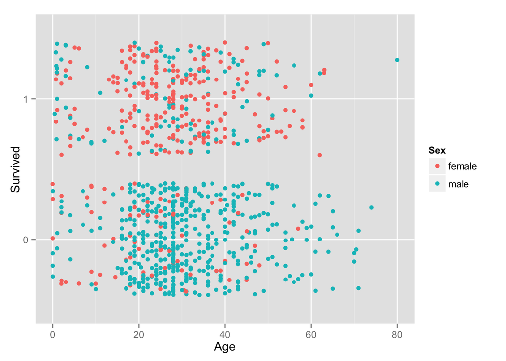

```r
ggplot(training, aes(Age, Survived, col=Sex)) + geom_jitter()
```

## Building Prediction Models

In order to build prediction models, we first need to divide our training set into a train and test set. The test set will be used to estimate our out-of-sample error rates for our various models.

```r
set.seed(31)
inTrain <- createDataPartition(y=training$Survived, p=0.7, list=FALSE)
train <- training[inTrain,]
test  <- training[-inTrain,]
```

## Model Building: Generalized Linear Model

```r
set.seed(953)
glmMod <- train(as.factor(Survived)~Age+Pclass+Sex+SibSp+Parch+Fare+Embarked, method='glm', data=train)
glmMod$finalModel
```

```
##
## Call:  NULL
##
## Coefficients:
## (Intercept)          Age       Pclass      Sexmale        SibSp
##    5.570972    -0.041709    -1.182506    -2.586397    -0.333733
##       Parch         Fare    EmbarkedQ    EmbarkedS
##   -0.029651     0.000801     0.044715    -0.521469
##
## Degrees of Freedom: 624 Total (i.e. Null);  616 Residual
## Null Deviance:       832.5
## Residual Deviance: 562.6     AIC: 580.6
```

We can plot the variable importance for the model. For linear models, this is the absolute value of the t-statistics for each predictor variable.

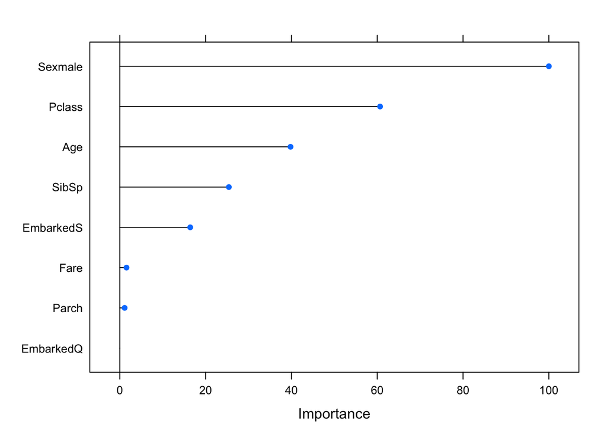

```r
plot(varImp(glmMod))
```

The Sex variable is ranked first. As seen in the final model, its coefficient for Sex = Male is negative, indicating survival is more likely for women than for men (which was perhaps expected).

We can then used the trained linear model to predict on the test data:

```r
predGLM <- predict(glmMod, test)
confusionMatrix(predGLM, test$Survived)
```

```
## Confusion Matrix and Statistics
##
##           Reference
## Prediction   0   1
##          0 137  25
##          1  27  77
##
##                Accuracy : 0.8045
##                  95% CI : (0.7517, 0.8504)
##     No Information Rate : 0.6165
##     P-Value [Acc > NIR] : 3.037e-11
##
##                   Kappa : 0.5881
##  Mcnemar's Test P-Value : 0.8897
##
##             Sensitivity : 0.8354
##             Specificity : 0.7549
##          Pos Pred Value : 0.8457
##          Neg Pred Value : 0.7404
##              Prevalence : 0.6165
##          Detection Rate : 0.5150
##    Detection Prevalence : 0.6090
##       Balanced Accuracy : 0.7951
##
##        'Positive' Class : 0
##
```

## Model Building: Gradient Boosting

```r
set.seed(5346)
trCl <- trainControl(method='cv', number=4, verboseIter=FALSE, allowParallel=TRUE)
gbmMod <- train(as.factor(Survived)~Age+Pclass+Sex+SibSp+Parch+Fare+Embarked, method='gbm', verbose=FALSE, data=train, trControl=trCl)
mean(gbmMod$resample$Accuracy)
```

```
## [1] 0.8208293
```

Predict on the test data:

```r
predGBM <- predict(gbmMod, test)
confusionMatrix(predGBM, test$Survived)
```

```
## Confusion Matrix and Statistics
##
##           Reference
## Prediction   0   1
##          0 144  22
##          1  20  80
##
##                Accuracy : 0.8421
##                  95% CI : (0.7926, 0.8838)
##     No Information Rate : 0.6165
##     P-Value [Acc > NIR] : 6.804e-16
##
##                   Kappa : 0.6648
##  Mcnemar's Test P-Value : 0.8774
##
##             Sensitivity : 0.8780
##             Specificity : 0.7843
##          Pos Pred Value : 0.8675
##          Neg Pred Value : 0.8000
##              Prevalence : 0.6165
##          Detection Rate : 0.5414
##    Detection Prevalence : 0.6241
##       Balanced Accuracy : 0.8312
##
##        'Positive' Class : 0
##
```

## Model Building: Random Forest

```r
set.seed(3576)
rfMod <- train(as.factor(Survived)~Age+Pclass+Sex+SibSp+Parch+Fare+Embarked, method='rf', data=train)
rfMod$finalModel
```

```
##
## Call:
##  randomForest(x = x, y = y, mtry = param$mtry)
##                Type of random forest: classification
##                      Number of trees: 500
## No. of variables tried at each split: 2
##
##         OOB estimate of  error rate: 16.8%
## Confusion matrix:
##     0   1 class.error
## 0 350  35  0.09090909
## 1  70 170  0.29166667
```

The out-of-bag estimate of the error rate, which estimates the error rate on new unseen data is 16.8%. We can use this trained random forest to predict on the testing set:

```r
predRF <- predict(rfMod, test)
confusionMatrix(predRF, test$Survived)
```

```
## Confusion Matrix and Statistics
##
##           Reference
## Prediction   0   1
##          0 149  26
##          1  15  76
##
##                Accuracy : 0.8459
##                  95% CI : (0.7968, 0.8871)
##     No Information Rate : 0.6165
##     P-Value [Acc > NIR] : <2e-16
##
##                   Kappa : 0.6672
##  Mcnemar's Test P-Value : 0.1183
##
##             Sensitivity : 0.9085
##             Specificity : 0.7451
##          Pos Pred Value : 0.8514
##          Neg Pred Value : 0.8352
##              Prevalence : 0.6165
##          Detection Rate : 0.5602
##    Detection Prevalence : 0.6579
##       Balanced Accuracy : 0.8268
##
##        'Positive' Class : 0
##
```

The accuracy on the test set is 84.6%, or equivalently, the error rate is 15.4%.

We can also take a look at the order of variable importance for the random forest model. The variable importance is computed by taking the out-of-bag samples for each tree (i.e. the samples not used in tree construction), taking a random permutation of the predictor variable value and putting these new OOB samples down each tree in the forest. The difference between the number of votes for the correct class in the variable-permuted OOB data and the number of votes in the original OOB data is the importance score for that variable. It is a measure of how sensitive the forest prediction is on the value of that particular variable.

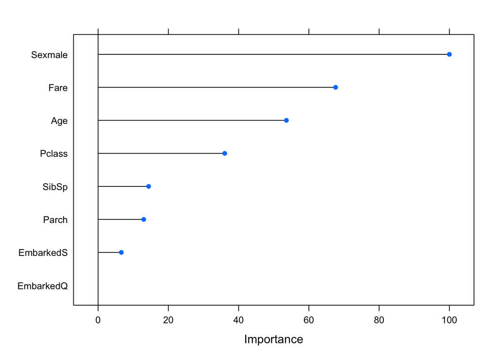

```r
plot(varImp(rfMod))
```

## SVM

```r
set.seed(123)
library(e1071)
svmMod <- svm(as.factor(Survived)~Sex, data=train)

predSVM <- predict(svmMod, test)
confusionMatrix(predSVM, test$Survived)
```

```
## Confusion Matrix and Statistics
##
##           Reference
## Prediction   0   1
##          0 140  27
##          1  24  75
##
##                Accuracy : 0.8083
##                  95% CI : (0.7557, 0.8538)
##     No Information Rate : 0.6165
##     P-Value [Acc > NIR] : 1.164e-11
##
##                   Kappa : 0.5922
##  Mcnemar's Test P-Value : 0.7794
##
##             Sensitivity : 0.8537
##             Specificity : 0.7353
##          Pos Pred Value : 0.8383
##          Neg Pred Value : 0.7576
##              Prevalence : 0.6165
##          Detection Rate : 0.5263
##    Detection Prevalence : 0.6278
##       Balanced Accuracy : 0.7945
##
##        'Positive' Class : 0
##
```

## Making a Kaggle Submission

First, we need to clean the testing set in the same way we treated the training set.

```r
# Note there are no missing Embarked values in the testing set
# Impute the Age variable using the same model we used for the training
testingNA <- testing[is.na(testing$Age),]
testingNoNA <- testing[!is.na(testing$Age),]
predAge <- round(predict(glm, newdata=testingNA), 0)
predAge[predAge<0] <- 0
testingNA$Age <- predAge
new_testing <- rbind(testingNA, testingNoNA)

# Impute the missing Fare variable in the testing set by taking the median of the Fare values
new_testing$Fare[is.na(new_testing$Fare)] <- median(new_testing$Fare, na.rm=TRUE)
```

```r
# Train a model on the full training set
rfmod <- train(as.factor(Survived)~Age+Pclass+Sex+SibSp+Parch+Fare+Embarked, method='rf', data=training)
submission <- data.frame(PassengerId=new_testing$PassengerId)
submission$Survived <- predict(rfmod, new_testing)
write.csv(submission, file='random_forest_r_submission1.csv', row.names=FALSE)
```

## Comparing results on the new_testing set: GLM, GBM, RF

```r
glmmod <- train(as.factor(Survived)~Age+Pclass+Sex+SibSp+Parch+Fare+Embarked, method='glm', data=training)
gbmmod <- train(as.factor(Survived)~Age+Pclass+Sex+SibSp+Parch+Fare+Embarked, method='gbm', verbose=FALSE, data=training)
resGLM <- predict(glmmod, new_testing)
resGBM <- predict(gbmmod, new_testing)
resRF <- predict(rfmod, new_testing)
```

```r
add <- as.numeric(resGLM) + as.numeric(resGBM) + as.numeric(resRF) # 3 for 000, 4 for 001, 5 for 011, 6 for 111
majority_pred <- ifelse(add < 5, '0', '1')

# New Kaggle predictions based on majority vote from our 3 models
submission <- data.frame(PassengerId=new_testing$PassengerId)
submission$Survived <- majority_pred
write.csv(submission, file='3modelvote_submission2.csv', row.names=FALSE)
```

## Combining Predictors

```r
predDF <- data.frame(predRF, predGBM, predGLM, predSVM, Survived=test$Survived)
combModFit <- train(Survived~., method='gam', data=predDF)
combPred <- predict(combModFit, predDF)

sum(predGLM==test$Survived)
```

```
## [1] 214
```

```r
sum(predGBM==test$Survived)
```

```
## [1] 224
```

```r
sum(predRF==test$Survived)
```

```
## [1] 225
```

```r
sum(combPred==test$Survived)
```

```
## [1] 227
```

# Trying out some Other Ideas

## Add a variable for Child/Adult

We will try adding a new factor variable that distinguishes children from adults. For those in the training set without an age, we will grep the name for the words “Miss” or “Master”. First, let’s make some exploratory plots.

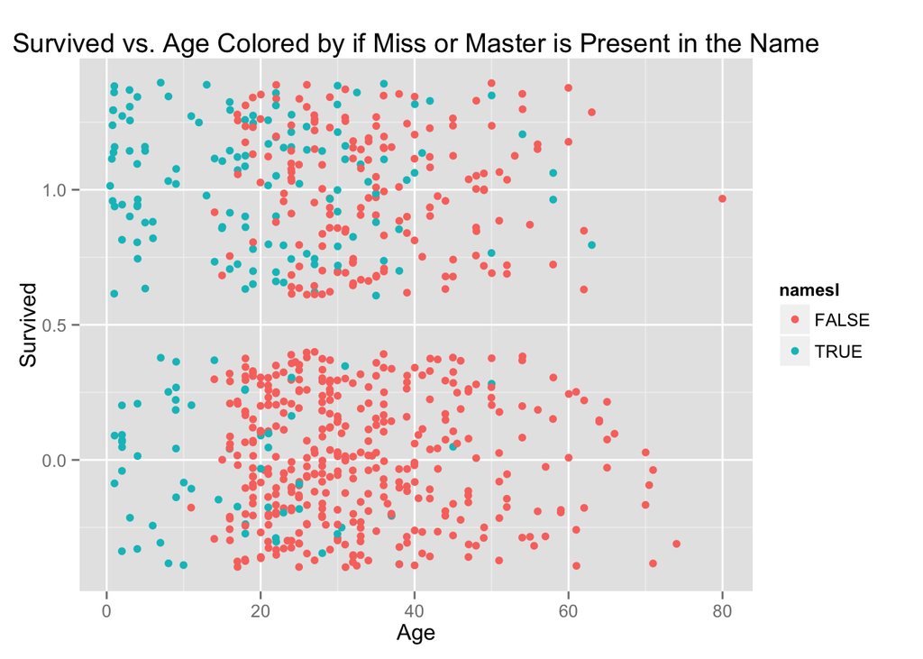

```r
# Load the training set and select only those samples where the Age is not NA
new_train <- read.csv('train.csv')
new_train$Embarked[new_train$Embarked==''] <- 'S'
new_train$Embarked <- droplevels(new_train$Embarked)
new_trainNoNA <- new_train[!is.na(new_train$Age),]

# Find those samples with Miss or Master in the name
names <- c('Miss', 'Master')
namesl <- grepl(paste(names, collapse='|'), new_trainNoNA$Name, ignore.case=TRUE)

# Plot Survived vs. Age colored by if Miss or Master is present in the name
ggplot(new_trainNoNA, aes(Age, Survived, col=namesl)) + geom_jitter() + ggtitle("Survived vs. Age Colored by if Miss or Master is Present in the Name")
```

This plot reveals that “Miss” and “Master” are typically indicative of children or young adults (e.g. including unmarried women).

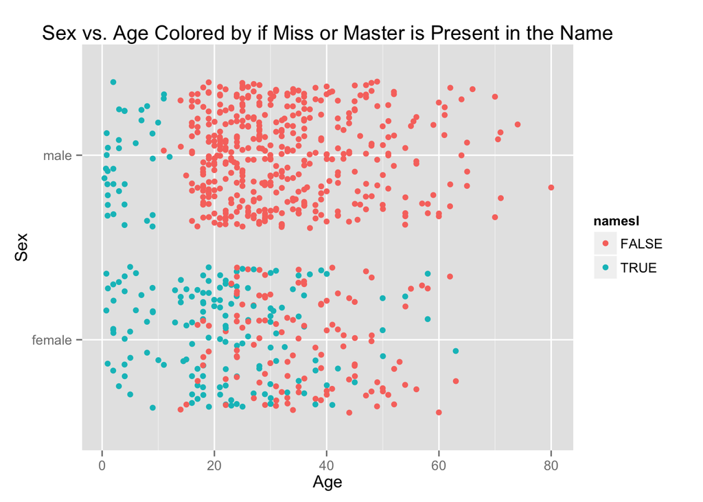

```r
# Plot Sex vs. Age colored by if Miss or Master is present in the name
ggplot(new_trainNoNA, aes(Age, Sex, col=namesl)) + geom_jitter() + ggtitle("Sex vs. Age Colored by if Miss or Master is Present in the Name")
```

The above plot shows that “Miss” is sometimes used for older women (perhaps those that are unmarried). However, “Master” seems to only be used for males below a certain age.

We can now create our new variable “ChildAdult”:

```r
new_trainNA <- new_train[is.na(new_train$Age),]

# Create ChildAdult variable
MissMaster <- grepl(paste(names, collapse='|'), new_trainNA$Name, ignore.case=TRUE)
new_trainNA$ChildAdult <- ifelse(MissMaster, 'Child', 'Adult')
new_trainNA$Age <- -1

# Same for new_trainNoNA
new_trainNoNA$ChildAdult <- ifelse(new_trainNoNA$Age < 19, 'Child', 'Adult')

# Join new_trainNoNA and new_trainNA
joined_train <- rbind(new_trainNoNA, new_trainNA)

# Set Survived as a factor variable so our predictions yield 0 or 1
joined_train$Survived <- as.factor(joined_train$Survived)
```

We can try to train a random forest with this new ChildAdult variable, but let’s first divide the training set into a train and test set:

```r
set.seed(731)
inTrain <- createDataPartition(y=joined_train$Survived, p=0.7, list=FALSE)
train <- joined_train[inTrain,]
test <- joined_train[-inTrain,]
```

```r
set.seed(8076)
new_rf <- train(Survived~Age+Pclass+Sex+SibSp+Parch+Fare+Embarked+ChildAdult, method='rf', data=train)

# Predict on the test set
pred <- predict(new_rf, test)
confusionMatrix(pred, test$Survived)
```

```
## Confusion Matrix and Statistics
##
##           Reference
## Prediction   0   1
##          0 149  37
##          1  15  65
##
##                Accuracy : 0.8045
##                  95% CI : (0.7517, 0.8504)
##     No Information Rate : 0.6165
##     P-Value [Acc > NIR] : 3.037e-11
##
##                   Kappa : 0.569
##  Mcnemar's Test P-Value : 0.003589
##
##             Sensitivity : 0.9085
##             Specificity : 0.6373
##          Pos Pred Value : 0.8011
##          Neg Pred Value : 0.8125
##              Prevalence : 0.6165
##          Detection Rate : 0.5602
##    Detection Prevalence : 0.6992
##       Balanced Accuracy : 0.7729
##
##        'Positive' Class : 0
##
```

The error rate on the test set is slightly worse than obtained with our previous random forest model.

## Impute Age and use ChildAdult

```r
train2 <- read.csv('train.csv')
train2$Embarked[train2$Embarked==''] <- 'S'
train2$Embarked <- droplevels(train2$Embarked)
train2$Age[is.na(train2$Age)] <- 0
train2NoNA <- train2[train2$Age != 0,]
train2NA <- train2[train2$Age == 0,]
glm <- train(Age ~ Pclass+Sex+SibSp+Parch+Fare+Embarked, method='glm', data=train2NoNA)
```

```r
pred <- round(predict(glm, newdata=train2NA),0)
# Make any negative ages = 0
pred[pred<0] <- 0
```

Now replace these predictions in the trainingNA dataset and row bind the NoNA dataset to this imputed data:

```r
train2NA$Age <- pred

#Create ChildAdult variable
MissMaster <- grepl(paste(names, collapse='|'), train2NA$Name, ignore.case=TRUE)
train2NA$ChildAdult <- ifelse(MissMaster, 'Child', 'Adult')
train2NoNA$ChildAdult <- ifelse(train2NoNA$Age < 19, 'Child', 'Adult')

training2 <- rbind(train2NA, train2NoNA)
training2$Survived <- as.factor(training2$Survived)
```

Divide the training2 samples into train and test sets:

```r
set.seed(111)
inTrain <- createDataPartition(y=training2$Survived, p=0.7, list=FALSE)
train <- training2[inTrain,]
test <- training2[-inTrain,]
```

Train the random forest:

```r
set.seed(435)
modrf <- train(Survived~Age+Pclass+Sex+SibSp+Parch+Fare+Embarked+ChildAdult, method='rf', data=train)

pred <- predict(modrf, test)
confusionMatrix(pred, test$Survived)
```

```
## Confusion Matrix and Statistics
##
##           Reference
## Prediction   0   1
##          0 152  33
##          1  12  69
##
##                Accuracy : 0.8308
##                  95% CI : (0.7803, 0.8738)
##     No Information Rate : 0.6165
##     P-Value [Acc > NIR] : 2.211e-14
##
##                   Kappa : 0.6277
##  Mcnemar's Test P-Value : 0.002869
##
##             Sensitivity : 0.9268
##             Specificity : 0.6765
##          Pos Pred Value : 0.8216
##          Neg Pred Value : 0.8519
##              Prevalence : 0.6165
##          Detection Rate : 0.5714
##    Detection Prevalence : 0.6955
##       Balanced Accuracy : 0.8016
##
##        'Positive' Class : 0
##
```

```r
set.seed(908)
modimp <- train(Survived~Age+Pclass+Sex+Fare+ChildAdult+SibSp, method='rf', data=train)
pred <- predict(modimp, test)
confusionMatrix(pred, test$Survived)
```

```
## Confusion Matrix and Statistics
##
##           Reference
## Prediction   0   1
##          0 147  30
##          1  17  72
##
##                Accuracy : 0.8233
##                  95% CI : (0.7721, 0.8672)
##     No Information Rate : 0.6165
##     P-Value [Acc > NIR] : 1.974e-13
##
##                   Kappa : 0.6171
##  Mcnemar's Test P-Value : 0.08005
##
##             Sensitivity : 0.8963
##             Specificity : 0.7059
##          Pos Pred Value : 0.8305
##          Neg Pred Value : 0.8090
##              Prevalence : 0.6165
##          Detection Rate : 0.5526
##    Detection Prevalence : 0.6654
##       Balanced Accuracy : 0.8011
##
##        'Positive' Class : 0
##
```

## Train the SVM with ChildAdult included

```r
set.seed(4018)
library(e1071)
modsvm <- svm(as.factor(Survived)~Age+Sex+Pclass+Fare+ChildAdult+SibSp+Embarked, data=train) # leaving Parch OR SibSp out
pred <- predict(modsvm, test)
confusionMatrix(pred, test$Survived)
```

```
## Confusion Matrix and Statistics
##
##           Reference
## Prediction   0   1
##          0 145  29
##          1  19  73
##
##                Accuracy : 0.8195
##                  95% CI : (0.768, 0.8638)
##     No Information Rate : 0.6165
##     P-Value [Acc > NIR] : 5.675e-13
##
##                   Kappa : 0.6112
##  Mcnemar's Test P-Value : 0.1939
##
##             Sensitivity : 0.8841
##             Specificity : 0.7157
##          Pos Pred Value : 0.8333
##          Neg Pred Value : 0.7935
##              Prevalence : 0.6165
##          Detection Rate : 0.5451
##    Detection Prevalence : 0.6541
##       Balanced Accuracy : 0.7999
##
##        'Positive' Class : 0
##
```